# Data Wrangling (Data Preprocessing)

Mid-term Assessment

Wan Yi Lam

30 April 2024

## **Setup**

```r
library(tidyverse)
library(magrittr)
library(dplyr)
library(knitr)
library(randomNames)
library(Hmisc)
```

## **Introduction**

Commonwealth Bank of Australia focus on providing both retail and commercial banking services in Australia, head of retail banking division would like to random check about secured and unsecured loans performances of five retail branches in January in order to better understand market trends and customers’ need.

In this report, there are two synthetic data sets with 120 observations created; one contains January loan applications details and status that the data set is managed by the loan department; when another data set is managed by retail middle office that contains personal information records of applicants in bank.

## **Data generation**

#### *Create First Data Set for “Loan applications”*

```r
holiday_date <- c(as.Date("2024-01-06"), as.Date("2024-01-07"), as.Date("2024-01-13"),as.Date("2024-01-14"),
                    as.Date("2024-01-20"), as.Date("2024-01-21"), as.Date("2024-01-26"),
                    as.Date("2024-01-27"), as.Date("2024-01-28"))
time_seq <- seq(from = as.Date("2024-01-02"),
                to   = as.Date("2024-01-31"),
                by   = 'day')
time_seq <- time_seq[!time_seq %in% holiday_date]

#Add application date
set.seed(2024)

ApplicationDate <- as.Date(sample(time_seq, 120, replace = TRUE))

LoanApp <- data.frame(ApplicationDate)
```

First of all, all weekends and public holiday in January need to be excluded all weekends and public holiday in January since those date are not a working day for bank. `holiday_date` is created which is a bank closing date vector & `time_seq` is a sequence indicate the time period in January. Then working date is subsetted by using `[!time_seq %in% holiday_date]` (Clemsang, 2022).

To create random `ApplicationDate` for 120 observations, `set.seed` is applied and also `as.Date` is added before `sample()` to ensure the column would become date data type. At this point, `as.data.frame` is applied to create *LoanApp* data frame structure.

```r
knitr::kable(LoanApp[1:5, , drop = FALSE])
```

| ApplicationDate |
| --- |
| 2024-01-03 |
| 2024-01-08 |
| 2024-01-18 |
| 2024-01-24 |
| 2024-01-18 |

```r
#Add application no
set.seed(2024)
LoanApp %<>% arrange(ApplicationDate)
LoanApp$ApplicationNo <- as.character(sort(sample(110000:150000, size = 120, replace = FALSE),
                      decreasing = FALSE))
```

Initially the order of `ApplicationDate` is arranged to show the distribution of loan application among date. The `LoanApp$ApplicationNo` is set up with 6 digits and each application no. should be unique in system, so `replace = FALSE`is applied. Also, the order of application no. sorts in ascending order to indicate the application order.

```r
knitr::kable(LoanApp[1:5,])
```

| ApplicationDate | ApplicationNo |
| --- | --- |
| 2024-01-02 | 110223 |
| 2024-01-02 | 110575 |
| 2024-01-02 | 110874 |
| 2024-01-02 | 110934 |
| 2024-01-03 | 111023 |

```r
#Add loan type
type <- c("HomeLoan", "CarLoan", "PersonalLoan")
set.seed(20214)
LoanApp$LoanType <- as.factor(sample(type, size = 120, replace = TRUE,
                                     prob = c(0.25, 0.4, 0.35)))
```

Home loan, car loan and unsecured personal loan are main loan types for retail banking customers. `LoanApp$LoanType` is focused on these three loan type, moreover, the number of application of different loan type would be slightly different in real world. Hence, the different probability among three loan type is applied to create relatively realistic data set.

```r
knitr::kable(LoanApp[1:5,])
```

| ApplicationDate | ApplicationNo | LoanType |
| --- | --- | --- |
| 2024-01-02 | 110223 | PersonalLoan |
| 2024-01-02 | 110575 | CarLoan |
| 2024-01-02 | 110874 | CarLoan |
| 2024-01-02 | 110934 | CarLoan |
| 2024-01-03 | 111023 | CarLoan |

```r
summary(LoanApp$LoanType)
```

```
##      CarLoan     HomeLoan PersonalLoan
##           44           30           46
```

```r
home <- LoanApp$LoanType == 'HomeLoan'
car <- LoanApp$LoanType == 'CarLoan'

#Add loan amount
set.seed(20214)
LoanApp$Amount <- (ifelse(home==TRUE, sample(c("300,000","400,000","500,000","600,000"),
                                             30, replace = TRUE),
                         ifelse(car==TRUE,sample(c("40,000","50,000","60,000","70,000","80,000"),
                                                               44, replace = TRUE), "40,000")))
LoanApp$Amount <- as.factor(LoanApp$Amount)

#Add loan tenor
set.seed(20214)
LoanApp$Tenor <- as.integer(ifelse(home==TRUE, sample(c(120,240,360), 30, replace = TRUE),
                                      ifelse(car==TRUE, sample(c(36,48,60), 44, replace = TRUE), 36)))
```

`Summary()` is applied to check th count of each loan type. Three loan types should be different in loan amount and loan tenor, since the price of a real estate and a car is huge difference in real life. `home` & `car` vectors are created and represented `LoanApp$LoanType` accordingly.

Also, testing in `ifelse()` is needed to set the return values for false element, to be simplified, unsecured personal loan amount is set to be “40,000” with tenor 36.

Hence, `ifelse()` is applied to test if `home` exists, amount “300,000”,“400,000”,“500,000” and “600,000” & tenor “120”, “240”, “360” will be random placed repeatably for 30 observations in new columns of `LoanApp$Amount` & `LoanApp$Tenor`.

Same as `home`, `ifelse()` is applied to test if `car` exists, amount “40,000”,“50,000”, “60,000”, “70,000”, “80,000” and tenor “36”, “48”, “60” will be random placed repeatably for 44 observations in new columns of `LoanApp$Amount` & `LoanApp$Tenor`.

If `home` & `car` is not existed, amount “40,000” & tenor “36” will be placed for unsecured personal loan in new columns of `LoanApp$Amount` & `LoanApp$Tenor`.

```r
knitr::kable(LoanApp[1:5,])
```

| ApplicationDate | ApplicationNo | LoanType | Amount | Tenor |
| --- | --- | --- | --- | --- |
| 2024-01-02 | 110223 | PersonalLoan | 40,000 | 36 |
| 2024-01-02 | 110575 | CarLoan | 70,000 | 36 |
| 2024-01-02 | 110874 | CarLoan | 60,000 | 60 |
| 2024-01-02 | 110934 | CarLoan | 40,000 | 36 |
| 2024-01-03 | 111023 | CarLoan | 80,000 | 36 |

```r
#Add customer no.
set.seed(2024)
LoanApp$CustomerNo <- as.character(sample(330000:550000, size = 120, replace = FALSE))

#Add customer name
set.seed(2024)
name.df <- data.frame(GENDER=sample(0:1, 120, replace=TRUE),
                      ETHNICITY=sample(1:6, 120, replace=TRUE))
LoanApp$CustomerName <- randomNames(gender=name.df$GENDER,
                          ethnicity=name.df$ETHNICITY, name.order="first.last")
```

Each customer no. should be unique in bank system, so `LoanApp$CustomerNo` is created as a new column in `LoanApp` data frame, with 6 digits in random and ranged from 330000 to 550000 that distinguished from the `LoanApp$ApplicationNo` .

On the other hand, customer name is created by using `randomNames()`. First, `name.df` is created to set the gender and ethnicity randomly placed for all 120 observations. For example, ethnicity codes represent “American Indian or Native Alaskan”,” Asian or Pacific Islander”, “Black (not Hispanic)”, “Hispanic”, “White (not Hispanic)” & “Middle-Eastern, Arabic” in package `randomNames`.

Later, `randomNames()` is applied in order to create a full name for `LoanApp$CustomerName` according to gender and ethnicity in `name.df` and also set the name order in first name and followed by last name.

```r
knitr::kable(LoanApp[1:5,])
```

| ApplicationDate | ApplicationNo | LoanType | Amount | Tenor | CustomerNo | CustomerName |
| --- | --- | --- | --- | --- | --- | --- |
| 2024-01-02 | 110223 | PersonalLoan | 40,000 | 36 | 416564 | Shafeeqa, el-Habibi |
| 2024-01-02 | 110575 | CarLoan | 70,000 | 36 | 375755 | Nathan, Lopez |
| 2024-01-02 | 110874 | CarLoan | 60,000 | 60 | 507040 | Tristan, Terry |
| 2024-01-02 | 110934 | CarLoan | 40,000 | 36 | 349871 | Sidney, Bentley |
| 2024-01-03 | 111023 | CarLoan | 80,000 | 36 | 337801 | Timothy, Mitchell |

```r
#Add application status
status <- c("Drawdown", "Processing", "Cancel")
set.seed(202)
LoanApp$ApplicationStatus <- as.character(sample(status, size = 120, replace = TRUE,
                                     prob = c(0.7, 0.22, 0.08)))

#Add missing value in application status column
set.seed(20214)
LoanApp %<>%
  mutate(rand = runif(120, min = 0, max = 1))
LoanApp <- mutate(LoanApp, ApplicationStatus = case_when(rand >= 0.05 ~ ApplicationStatus))

#Exclude the rand value for inserting NA
LoanApp <- LoanApp[,1:8]
```

For the purpose of imitating the real world status, application status, which is including “Drawdown”, “Processing” & “Cancel”, is inserted to all observation randomly by setting the different proportion to create a new column `LoanApp$ApplicationStatus`.

#### *“Loan applications” Data Set*

Loan applications data set is created with total 120 observations and 8 variables with different data type, including date, character, factor and integer. Moreover, the data set is exported to CSV file in working directory.

```r
str(LoanApp)
```

```
## 'data.frame':    120 obs. of  8 variables:
##  $ ApplicationDate  : Date, format: "2024-01-02" "2024-01-02" ...
##  $ ApplicationNo    : chr  "110223" "110575" "110874" "110934" ...
##  $ LoanType         : Factor w/ 3 levels "CarLoan","HomeLoan",..: 3 1 1 1 1 3 1 1 1 1 ...
##  $ Amount           : Factor w/ 9 levels "300,000","40,000",..: 2 8 6 2 9 2 4 2 2 8 ...
##  $ Tenor            : int  36 36 60 36 36 36 48 48 60 48 ...
##  $ CustomerNo       : chr  "416564" "375755" "507040" "349871" ...
##  $ CustomerName     : chr  "Shafeeqa, el-Habibi" "Nathan, Lopez" "Tristan, Terry" "Sidney, Bentley" ...
##  $ ApplicationStatus: chr  "Drawdown" "Drawdown" "Drawdown" "Drawdown" ...
```

```r
head(LoanApp, 10)
```

|  | ApplicationDate | ApplicationNo | LoanType | Amount | Tenor | CustomerNo | CustomerName | ApplicationStatus |
| --- | --- | --- | --- | --- | --- | --- | --- | --- |
| 1 | 2024-01-02 | 110223 | PersonalLoan | 40,000 | 36 | 416564 | Shafeeqa, el-Habibi | Drawdown |
| 2 | 2024-01-02 | 110575 | CarLoan | 70,000 | 36 | 375755 | Nathan, Lopez | Drawdown |
| 3 | 2024-01-02 | 110874 | CarLoan | 60,000 | 60 | 507040 | Tristan, Terry | Drawdown |
| 4 | 2024-01-02 | 110934 | CarLoan | 40,000 | 36 | 349871 | Sidney, Bentley | Drawdown |
| 5 | 2024-01-03 | 111023 | CarLoan | 80,000 | 36 | 337801 | Timothy, Mitchell | Drawdown |
| 6 | 2024-01-03 | 111154 | PersonalLoan | 40,000 | 36 | 457998 | Marshall, Mcveigh | Processing |
| 7 | 2024-01-03 | 111384 | CarLoan | 50,000 | 48 | 363802 | Peyton, Jones | Drawdown |
| 8 | 2024-01-03 | 111681 | CarLoan | 40,000 | 48 | 452107 | Janiva, Williams | NA |
| 9 | 2024-01-03 | 111760 | CarLoan | 40,000 | 60 | 414897 | Tabeion, Conover | Drawdown |
| 10 | 2024-01-03 | 111988 | CarLoan | 70,000 | 48 | 402875 | Maren, Moreno | Drawdown |

```r
#Export to CSV file in working directory
write.csv(LoanApp, file = "LoanApp.csv")
```

#### *Create Second Data Set for “Retail Banking Customer”*

```r
#Create 5 branch codes representing 5 retail branches
set.seed(2024)
BranchCode <- as.factor(sample(c(7627, 7628, 7629, 7630, 7631), size = 120, replace =TRUE,
                               prob = c(0.3, 0.2, 0.25, 0.1, 0.15)))

#Subset the customer no. & customer name from previous data set
CustomerNo <- LoanApp$CustomerNo
CustomerName <- LoanApp$CustomerName

#Create a new data frame for Banking customer
RetailBankingCustomer <- data.frame(BranchCode, CustomerNo, CustomerName)
```

To commence with, this data set called *RetailBankingCustomer* would contain some personal information in order to get a better understanding of each customer’s financial status. Each retail customer is assigned to and followed by a retail branch. In this case, 5 branch codes are created repeatably in random representing 5 retail branches and named the vector of `BranchCode`.

Besides, the `CustomerNo` & `CustomerName` are subset from previous *LoanApp* data set in order to maintain the consistency of banking system records. Then, data frame `RetailBankingCustomer` are constructed by `BranchCode`, `CustomerNo` and `CustomerName`.

```r
knitr::kable(RetailBankingCustomer[1:5,])
```

| BranchCode | CustomerNo | CustomerName |
| --- | --- | --- |
| 7631 | 416564 | Shafeeqa, el-Habibi |
| 7629 | 375755 | Nathan, Lopez |
| 7628 | 507040 | Tristan, Terry |
| 7628 | 349871 | Sidney, Bentley |
| 7629 | 337801 | Timothy, Mitchell |

```r
#add customer type
type <- c("Premier Banking", "General Banking")
set.seed(2024)
RetailBankingCustomer$CustomerType <- sample(type, size = 120, replace = TRUE, prob=c("0.4","0.6"))

RetailBankingCustomer$CustomerType <- factor(RetailBankingCustomer$CustomerType,
                                             levels = c("General Banking","Premier Banking"), ordered = TRUE)
```

To create realistic synthetic data, customer type includes “Premier Banking” & “General Banking” that is also created for each customer. It is a indicator of the relationship between customer and bank and could build up customer loyalty, since Premier Banking customers trend to maintain large amount of assets in bank and engage more banking services.

Hence,`RetailBankingCustomer$CustomerType` is created and placed repeatably for all observations by slightly different proportion. In addition, `RetailBankingCustomer$CustomerType` is changed to be ordered factor, since it is an ordinal variable representing the assets level of customers that maintained in bank.

```r
knitr::kable(RetailBankingCustomer[1:5,])
```

| BranchCode | CustomerNo | CustomerName | CustomerType |
| --- | --- | --- | --- |
| 7631 | 416564 | Shafeeqa, el-Habibi | Premier Banking |
| 7629 | 375755 | Nathan, Lopez | General Banking |
| 7628 | 507040 | Tristan, Terry | Premier Banking |
| 7628 | 349871 | Sidney, Bentley | Premier Banking |
| 7629 | 337801 | Timothy, Mitchell | General Banking |

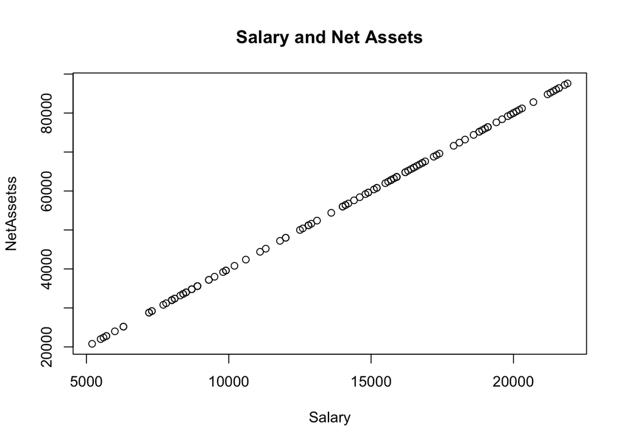

```r
#Create Correlated Random Variables
#salary <-> net_assets
set.seed(202)
correlated <- data.frame(n = 120,
                         Salary = round(runif(n = 120, min = 5000, max = 22000),-2))
set.seed(202)
correlated %<>%
  mutate(difference = rnorm(n = 120, mean = 0, sd = 3))

set.seed(202)
correlated %<>%
  mutate(NetAssets = (Salary * 4) + difference)

plot(x = correlated$Salary,
     y = correlated$NetAssets,
     main = "Salary and Net Assets",
     xlab = "Salary",
     ylab = "NetAssetss")
```

```r
RetailBankingCustomer$Salary <- cbind(correlated$Salary)
RetailBankingCustomer$NetAssets <- cbind(correlated$NetAssets)
```

To create a pair of correlated random variables, *salary* and *net assets* are chosen, as it is assumed that the salary amount is higher, the net assets in bank trend to be larger as the same times. Moreover, both salary and net assets are vital elements of credit approval for loan in real life.

First of all, `correlated` data frame is created, meanwhile `Salary` column is also created by using `runif()` for all observations between 5,000 and 22,000, and round up to hundred. Secondly, `difference` is normally distributed with a mean of 0 and a standard deviation of 3 to represent the difference saving hobbits among all customers. Thirdly, `NetAssets` is summed by `salary amount*4 + difference`(Data Wrangling Course Note, 2024).

After creating `Salary` & `NetAssets` column, `cbind()` is used for combining those two columns into the existing `RetailBankingCustomer` data frame.

```r
knitr::kable(RetailBankingCustomer[1:5,])
```

| BranchCode | CustomerNo | CustomerName | CustomerType | Salary | NetAssets |
| --- | --- | --- | --- | --- | --- |
| 7631 | 416564 | Shafeeqa, el-Habibi | Premier Banking | 7200 | 28796.60 |
| 7629 | 375755 | Nathan, Lopez | General Banking | 16400 | 65598.68 |
| 7628 | 507040 | Tristan, Terry | Premier Banking | 10600 | 42398.99 |
| 7628 | 349871 | Sidney, Bentley | Premier Banking | 8500 | 33997.46 |
| 7629 | 337801 | Timothy, Mitchell | General Banking | 11300 | 45199.56 |

```r
#Add occupation for each customer
Occupation <- factor(c("Worker", "Officer","Supervisor", "Manager", "Director"), levels=c("Worker", "Officer","Supervisor", "Manager", "Director"), order=TRUE)
set.seed(1990)
RetailBankingCustomer$Occupation <- sample(Occupation, 120, replace =TRUE,
                                           prob = c("0.07", "0.18", "0.31", "0.31", "0.1"))

#Subset the application no. from previous data set
ApplicationNo <- LoanApp$ApplicationNo
RetailBankingCustomer <- data.frame(RetailBankingCustomer, ApplicationNo)
```

To make each customer background to become solid and reliable, occupation for each customer is also created that indicates the position code of the customer’s employment stored in banking system for references. `Occupation` is created as ordered factor because the salary level is usually related to the occupation level. However, salary amount would be affected by other factor, business natural also means business industry. It is reasonable that the salary amount difference of each occupation could be larger than we thought.

On the other hand, `ApplicationNo` is subset from previous *LoanApp* data set, since retail branch need to follow up the banking services customers applied. Then, `ApplicationNo` also added to data set of `RetailBankingCustomer`.

```r
knitr::kable(RetailBankingCustomer[1:5,])
```

| BranchCode | CustomerNo | CustomerName | CustomerType | Salary | NetAssets | Occupation | ApplicationNo |
| --- | --- | --- | --- | --- | --- | --- | --- |
| 7631 | 416564 | Shafeeqa, el-Habibi | Premier Banking | 7200 | 28796.60 | Manager | 110223 |
| 7629 | 375755 | Nathan, Lopez | General Banking | 16400 | 65598.68 | Officer | 110575 |
| 7628 | 507040 | Tristan, Terry | Premier Banking | 10600 | 42398.99 | Supervisor | 110874 |
| 7628 | 349871 | Sidney, Bentley | Premier Banking | 8500 | 33997.46 | Manager | 110934 |
| 7629 | 337801 | Timothy, Mitchell | General Banking | 11300 | 45199.56 | Manager | 111023 |

```r
#add missing value
set.seed(202)
RetailBankingCustomer %<>%
  mutate(random = runif(120, min = 0, max = 1))

RetailBankingCustomer %<>%
  mutate(Salary = case_when(random >= 0.06 ~ Salary))

#exclude the random column for inserting NA
RetailBankingCustomer <- RetailBankingCustomer[,1:8]
```

```r
str(RetailBankingCustomer)
```

```
## 'data.frame':    120 obs. of  8 variables:
##  $ BranchCode   : Factor w/ 5 levels "7627","7628",..: 5 3 2 2 3 2 3 3 5 1 ...
##  $ CustomerNo   : chr  "416564" "375755" "507040" "349871" ...
##  $ CustomerName : chr  "Shafeeqa, el-Habibi" "Nathan, Lopez" "Tristan, Terry" "Sidney, Bentley" ...
##  $ CustomerType : Ord.factor w/ 2 levels "General Banking"<..: 2 1 2 2 1 2 1 1 2 1 ...
##  $ Salary       : num [1:120, 1] 7200 16400 10600 8500 11300 18300 8400 8700 12500 15900 ...
##  $ NetAssets    : num [1:120, 1] 28797 65599 42399 33997 45200 ...
##  $ Occupation   : Ord.factor w/ 5 levels "Worker"<"Officer"<..: 4 2 3 4 4 4 3 4 4 3 ...
##  $ ApplicationNo: chr  "110223" "110575" "110874" "110934" ...
```

```r
head(RetailBankingCustomer, 10)
```

|  | BranchCode | CustomerNo | CustomerName | CustomerType | Salary | NetAssets | Occupation | ApplicationNo |
| --- | --- | --- | --- | --- | --- | --- | --- | --- |
| 1 | 7631 | 416564 | Shafeeqa, el-Habibi | Premier Banking | 7200 | 28796.60 | Manager | 110223 |
| 2 | 7629 | 375755 | Nathan, Lopez | General Banking | 16400 | 65598.68 | Officer | 110575 |
| 3 | 7628 | 507040 | Tristan, Terry | Premier Banking | 10600 | 42398.99 | Supervisor | 110874 |
| 4 | 7628 | 349871 | Sidney, Bentley | Premier Banking | 8500 | 33997.46 | Manager | 110934 |
| 5 | 7629 | 337801 | Timothy, Mitchell | General Banking | 11300 | 45199.56 | Manager | 111023 |
| 6 | 7628 | 457998 | Marshall, Mcveigh | Premier Banking | 18300 | 73195.71 | Manager | 111154 |
| 7 | 7629 | 363802 | Peyton, Jones | General Banking | 8400 | 33597.67 | Supervisor | 111384 |
| 8 | 7629 | 452107 | Janiva, Williams | General Banking | 8700 | 34794.20 | Manager | 111681 |
| 9 | 7631 | 414897 | Tabeion, Conover | Premier Banking | 12500 | 50000.94 | Manager | 111760 |
| 10 | 7627 | 402875 | Maren, Moreno | General Banking | 15900 | 63601.41 | Supervisor | 111988 |

```r
#export to be csv file
write.csv(RetailBankingCustomer, file = "RetailBankingCustomer.csv")
```

## **Merging data sets**

```r
report <- LoanApp %>%
  left_join(RetailBankingCustomer, by = c("ApplicationNo"="ApplicationNo", "CustomerNo"="CustomerNo", "CustomerName"="CustomerName"))
```

By checking both *LoanApp* & *RetailBankingCustomer* data sets structure, we found that `ApplicationNo`, `CustomerNo` & `CustomerName` are existed in both data sets, so two data sets could be merged together by using `left_join()` and formed a new data frame called *report*. Therefore, we could obtain a report that includes 120 observations of loan application information in detail sorted by date in January, and followed by the personal information of the applicants.

When reading the *report*, it could be easy to identify the total no. of loan application are successfully drawdwon of home loan, car loan & personal loan particularly and also identify which retail branch could achieve better performance in loan sector that obtained more number of drawdown loans.

## **Checking structure of combined data**

```r
#check data type for conversions
report %>% str()
```

```
## 'data.frame':    120 obs. of  13 variables:
##  $ ApplicationDate  : Date, format: "2024-01-02" "2024-01-02" ...
##  $ ApplicationNo    : chr  "110223" "110575" "110874" "110934" ...
##  $ LoanType         : Factor w/ 3 levels "CarLoan","HomeLoan",..: 3 1 1 1 1 3 1 1 1 1 ...
##  $ Amount           : Factor w/ 9 levels "300,000","40,000",..: 2 8 6 2 9 2 4 2 2 8 ...
##  $ Tenor            : int  36 36 60 36 36 36 48 48 60 48 ...
##  $ CustomerNo       : chr  "416564" "375755" "507040" "349871" ...
##  $ CustomerName     : chr  "Shafeeqa, el-Habibi" "Nathan, Lopez" "Tristan, Terry" "Sidney, Bentley" ...
##  $ ApplicationStatus: chr  "Drawdown" "Drawdown" "Drawdown" "Drawdown" ...
##  $ BranchCode       : Factor w/ 5 levels "7627","7628",..: 5 3 2 2 3 2 3 3 5 1 ...
##  $ CustomerType     : Ord.factor w/ 2 levels "General Banking"<..: 2 1 2 2 1 2 1 1 2 1 ...
##  $ Salary           : num [1:120, 1] 7200 16400 10600 8500 11300 18300 8400 8700 12500 15900 ...
##  $ NetAssets        : num [1:120, 1] 28797 65599 42399 33997 45200 ...
##  $ Occupation       : Ord.factor w/ 5 levels "Worker"<"Officer"<..: 4 2 3 4 4 4 3 4 4 3 ...
```

```r
report %>% head(.,8)
```

|  | ApplicationDate | ApplicationNo | LoanType | Amount | Tenor | CustomerNo | CustomerName | ApplicationStatus | BranchCode | CustomerType | Salary | NetAssets | Occupation |
| --- | --- | --- | --- | --- | --- | --- | --- | --- | --- | --- | --- | --- | --- |
| 1 | 2024-01-02 | 110223 | PersonalLoan | 40,000 | 36 | 416564 | Shafeeqa, el-Habibi | Drawdown | 7631 | Premier Banking | 7200 | 28796.60 | Manager |
| 2 | 2024-01-02 | 110575 | CarLoan | 70,000 | 36 | 375755 | Nathan, Lopez | Drawdown | 7629 | General Banking | 16400 | 65598.68 | Officer |
| 3 | 2024-01-02 | 110874 | CarLoan | 60,000 | 60 | 507040 | Tristan, Terry | Drawdown | 7628 | Premier Banking | 10600 | 42398.99 | Supervisor |
| 4 | 2024-01-02 | 110934 | CarLoan | 40,000 | 36 | 349871 | Sidney, Bentley | Drawdown | 7628 | Premier Banking | 8500 | 33997.46 | Manager |
| 5 | 2024-01-03 | 111023 | CarLoan | 80,000 | 36 | 337801 | Timothy, Mitchell | Drawdown | 7629 | General Banking | 11300 | 45199.56 | Manager |
| 6 | 2024-01-03 | 111154 | PersonalLoan | 40,000 | 36 | 457998 | Marshall, Mcveigh | Processing | 7628 | Premier Banking | 18300 | 73195.71 | Manager |
| 7 | 2024-01-03 | 111384 | CarLoan | 50,000 | 48 | 363802 | Peyton, Jones | Drawdown | 7629 | General Banking | 8400 | 33597.67 | Supervisor |
| 8 | 2024-01-03 | 111681 | CarLoan | 40,000 | 48 | 452107 | Janiva, Williams | NA | 7629 | General Banking | 8700 | 34794.20 | Manager |

```r
#amend the column from vector to numeric
report$Salary <- as.numeric(report$Salary)
report$NetAssets <- as.numeric(report$NetAssets)

#amend tenor to be an orderd factor
report$Tenor %>% unique()
```

```
## [1]  36  60  48 360 240 120
```

```r
report$Tenor <- factor(report$Tenor, levels = c("36","48","60","120","240","360"), ordered = TRUE)
```

Before data type conversions, using `str()` and `head()` to check the data types in *report*. Then, both `Salary` and `NetAssets` columns is required to amend from vector to numeric by using `as.numeric()`. Also, applying `unique()` to check the unique value in `Tenor` column and rearrange the levels and set the order by `factor()`.

## **Generate summary statistics**

```r
#Group by Loan Type, the distribution of salary amount
report %>% group_by(LoanType) %>%
  summarise(First_quantile = quantile(Salary, 0.25, na.rm = TRUE),
            Mean = mean(Salary, na.rm = TRUE),
            Median = median(Salary, na.rm = TRUE),
            Third_quantile = quantile(Salary, 0.75, na.rm = TRUE),
            SD = sd(Salary,na.rm = TRUE),
            No_of_App = n(),
            missing = sum(is.na(Salary)))
```

| LoanType | First_quantile | Mean | Median | Third_quantile | SD | No_of_App | missing |
| --- | --- | --- | --- | --- | --- | --- | --- |
| CarLoan | 8700 | 13653.66 | 12800 | 16600 | 4547.862 | 44 | 3 |
| HomeLoan | 12900 | 15482.76 | 16700 | 19100 | 4485.856 | 30 | 1 |
| PersonalLoan | 9200 | 13900.00 | 14700 | 16375 | 4483.147 | 46 | 2 |

In order to know about the performance among three loan types, `group_by()` is applied to `LoanType`, it could find out the statistics summary of each loan type. Then,`summarise()` the salary amount for 120 customers. In statistics, first and third quantiles indicate the 25% and 75% of probability distribution of customers applying in different type of loan, so those have to be calculated separately. Also, `na.rm = TRUE` is adopted in each calculation to make sure all missing value would be removed before calculation since `sum(is.na())` is used to find out missing value of salary amount in `report` data set.

Comparing to the median salary amount of Car Loan & Personal Loan, the median salary amount of Home Loan is relatively higher than other two types of loan. This is consistent with the real life situation since the loan amount of Home Loan is relatively higher and the requirement of strong repayment ability is demanding to address the variability of interest rate.

## **Scanning data**

```r
#scan missing value
colSums(is.na(report))
```

```
##   ApplicationDate     ApplicationNo          LoanType            Amount
##                 0                 0                 0                 0
##             Tenor        CustomerNo      CustomerName ApplicationStatus
##                 0                 0                 0                 6
##        BranchCode      CustomerType            Salary         NetAssets
##                 0                 0                 6                 0
##        Occupation
##                 0
```

```r
#convert the missing value to "NoResponse" in ApplicationStatus
report$ApplicationStatus %<>% replace_na("NoResponse")

#replace the missing value by salary mean
report$Salary <- impute(report$Salary, fun = mean)

#convert the data type of ApplicationStatus to be factor
report$ApplicationStatus <- as.factor(report$ApplicationStatus)

#check again the report data set
report %>% summary()
```

```
##
##  6 values imputed to 14214.04
```

```
##  ApplicationDate      ApplicationNo              LoanType      Amount
##  Min.   :2024-01-02   Length:120         CarLoan     :44   40,000 :54
##  1st Qu.:2024-01-08   Class :character   HomeLoan    :30   70,000 :16
##  Median :2024-01-16   Mode  :character   PersonalLoan:46   500,000:12
##  Mean   :2024-01-16                                        50,000 : 9
##  3rd Qu.:2024-01-24                                        300,000: 7
##  Max.   :2024-01-31                                        80,000 : 7
##                                                            (Other):15
##  Tenor     CustomerNo        CustomerName        ApplicationStatus BranchCode
##  36 :62   Length:120         Length:120         Cancel    : 8      7627:40
##  48 :16   Class :character   Class :character   Drawdown  :85      7628:28
##  60 :12   Mode  :character   Mode  :character   NoResponse: 6      7629:26
##  120:11                                         Processing:21      7630: 9
##  240: 6                                                            7631:17
##  360:13
##
##           CustomerType     Salary        NetAssets          Occupation
##  General Banking:68    Min.   : 6300   Min.   :20798   Worker    : 9
##  Premier Banking:52    1st Qu.: 9875   1st Qu.:35599   Officer   :16
##                        Median :14500   Median :58004   Supervisor:35
##                        Mean   :14214   Mean   :55137   Manager   :53
##                        3rd Qu.:17325   3rd Qu.:69299   Director  : 7
##                        Max.   :21900   Max.   :87601
##
```

```r
#export to be csv file
write.csv(report, file = "Report.csv")
```

Regarding to scan the missing value in whole data frame, `colSums(is.na())` is applied and the total number of missing value in each column would be displayed. As there are 6 missing values found in `ApplicationStatus` and `Salary` accordingly.

Application status in bank system would remain NA while no response from customer, hence the missing value could be simply replaced by `replace_na()` to inserting “NoResponse”.

Moreover, salary column is numeric data type, `impute(., fun = mean)` could be applied to compute the average salary amount of all the customer and inserted to those six missing value in order to complete the data set.

As the result, `summary()` is applied to final check if those missing values are handled properly, and also, summarising data are provided that the *frequency* of each factor columns and statistical data with *mean*, *median*, and *range* for each numeric columns. Besides, the *report* data frame is exported to be csv file.

## **Reference list**

Wickham H, Averick M, Bryan J, Chang W, McGowan LD, François R, Grolemund G, Hayes A, Henry L, Hester J, Kuhn M, Pedersen TL, Miller E, Bache SM, Müller K, Ooms J, Robinson D, Seidel DP, Spinu V, Takahashi K, Vaughan D, Wilke C, Woo K, Yutani H (2019). “Welcome to the tidyverse.” *Journal of Open Source Software*, *4*(43), 1686. doi:10.21105/joss.01686 https://doi.org/10.21105/joss.01686.

Bache S, Wickham H (2022). *magrittr: A Forward-Pipe Operator for R*. R package version 2.0.3, [https://CRAN.R-project.org/package=magrittr](https://cran.r-project.org/package=magrittr).

Wickham H, François R, Henry L, Müller K, Vaughan D (2023). *dplyr: A Grammar of Data Manipulation*. R package version 1.1.4, [https://CRAN.R-project.org/package=dplyr](https://cran.r-project.org/package=dplyr).

Xie Y (2023). *knitr: A General-Purpose Package for Dynamic Report Generation in R*. R package version 1.45, https://yihui.org/knitr/.

Yihui Xie (2015) Dynamic Documents with R and knitr. 2nd edition. Chapman and Hall/CRC. ISBN 978-1498716963

Yihui Xie (2014) knitr: A Comprehensive Tool for Reproducible Research in R. In Victoria Stodden, Friedrich Leisch and Roger D. Peng, editors, Implementing Reproducible Computational Research. Chapman and Hall/CRC. ISBN 978-1466561595

Damian W. Betebenner (2021). randomNames: Function for Generating Random Names and a Dataset. (R package version 1.5-0.0 URL https://cran.r-project.org/package=randomNames

Harrell Jr F (2024). *Hmisc: Harrell Miscellaneous*. R package version 5.1-2, [https://CRAN.R-project.org/package=Hmisc](https://cran.r-project.org/package=Hmisc).

Data Wrangling Course Note (2024), Generating Synthetic Data, course website, accessed 27 April 2024. http://rare-phoenix-161610.appspot.com/secured/demos/Generating-Synthetic-Data.html

Clemsang (2022), Generating a random date with exceptions in R, Stackoverflow website, accessed 27 April 2024. https://stackoverflow.com/questions/74799432/generating-a-random-date-with-exceptions-in-r

Data Wrangling Course Note (2024), Module 5 Scan: Missing Values, course website, accessed 28 April 2024. http://rare-phoenix-161610.appspot.com/secured/Module_05.html#Replace_the_missing_value(s)_with_the_mean,_median_or_mode

Applied Analytics Module 2 Note (2024), Module 2 Descriptive Statistics through Visualisation, course website, accessed 18 April 2024. https://astral-theory-157510.appspot.com/secured/MATH1324_Module_02.html (https://astral-theory-157510.appspot.com/secured/MATH1324_Module_02.html)